# Stringovi i rad sa stringovima

String predstavlja tekstualni tip podataka. String možemo posmatrati kao sekvencu odnosno niz znakova (karaktera).

U programskom jeziku Python string konstante se zapisuju unutar jednostrukih (`'abc'`) ili dvostrukih (`"abc"`) navodnika.

Postoje i višelinijski stringovi koji se navode sa tri znaka navodnika: `"""` ili `'''`.

```python
print('''Neki tekst
koji pišemo u
nekoliko redova''')
```

```
Neki tekst
koji pišemo u
nekoliko redova
```

Korisnik sa tastature unosi sadržaj u obliku stringa koristeći dostupne znakove (mala i velika slova, cifre, specijalni karakteri poput znakova računskih opseracija, $, @, ! itd).

Kada korisnik klikne dugme `Enter` to se beleži kao takozvani newline karakter (zapisuje se kao `'\n'`). Ovaj karakter možemo navoditi i unutar stringova za prelazak u novi red.

```python
print("Pišemo neki tekst pa \nprelazimo u novi red.")
```

```
Pišemo neki tekst pa
prelazimo u novi red.
```

Još jedan takav karakter je '\t' koji dobijamo klikom na dugme `tab`. Ubacivanje ovog karaktera u string ima efekat pomeranje za 1 tab.

```python
print("Pišemo neki tekst pa\tmalo odmaknemo ostatak.")
```

```
Pišemo neki tekst pa	malo odmaknemo ostatak.
```

Obratite pažnju da ovi karakteri predstavljaju jedan karakter iako se zapisuju iz 2 znaka u izvornom kodu. Interpreter (ili kompajler) pretvara ova 2 znaka u 1 karakter. Najčešće počinje `escape` znakom (`\`) pa se stringovi koji sadrže ovakve karaktere nazivaju escape sekvencama.

## Character encoding - kodni raspored

Enkodiranje karaktera se koristi za reprezentaciju određenog seta karaktera koje upotrebljava određeni kodni sisitem. U tom svetlu definišemo karakter kao najmanju jedinicu teksta koja ima značenje - semantičku vrednost.

U nastavku će biti navedeni neki od najčešće korišćenih kodnih sisitema u računarstvu.

### ASCII (American Standard Code for Information Interchange)

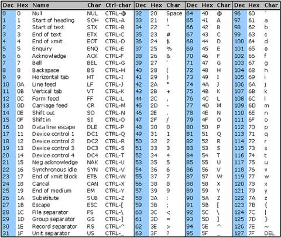

Baziran je na engleskom alfabetu, ASCII enkodira određenih 128 karaktera u sedmobitne brojeve. Razvijan je 60ih godina prošlog veka. ASCII sadrži 95 karaktera koji se mogu štampati i to su mala slova (a-z), velika slova (A-Z), specijalni znaci (!,#, $, %...) i cifre (0-9). Originalan ASCII sadrži još 33 kontrolna koda koja se ne mogu štampati. Većina ovih znakova su se koristili za teleprintere i mnogi se danas više ne koriste.

Iz tabele se može videti da se svakom znaku dodeljuje brojna vrednost. Primer: malo slovo `i` bi se ASCII-jem enkodovalo u binarno 1101001, heksadecimalno 69 i decimalno 105. Često se u implementaciji različitih string funkcija koriste numeričke vrednosti karaktera jer su pogodnije za aritmetička izračunavanja.

Dostupne su funkcije za konverziju karaktera u numerički kod i obrnuto.

```python
print("Numerički kod za karakter a je", ord("a"))
print("Numerički kod za karakter A je", ord("A"))

print("Karakter za kod 35 je", chr(35))
print("Karakter za kod 80 je", chr(80))
```

```
Numerički kod za karakter a je 97
Numerički kod za karakter A je 65
Karakter za kod 35 je #
Karakter za kod 80 je P
```

Python 2 podržava ASCII standard. Jedan od problema prilikom korišćenja ASCII sistema je nepostojanje podrške za zapisivanje slova onih svetskih jezika čija slova odstupaju od engleskog alfabeta.

### Unicode

Unicode je standard računarske industrije za konzistento enkodovanje, reprezentaciju i rukovanje tekstom zapisanom u većini svetskih jezika. Unicode je noviji sistem u odnosu na ASCII tako da podržava širi opseg znakova, ali je dizajniran kao proširenje ASCII standarda.

Postoji više verzija Unicode-a. UTF-8 je Unicode transformaciona šema sa osnovnom jedinicom od 8 bita. Pomoću nje se znak zapisuje pomoću 1, 2 ili 3 bajta u zavisnosti od znaka koji se prikazuje. UTF-8 je format koji podržava i latinično i ćirilično pismo, kao i pismo većine evropskih jezika.

Python 3 podržava Unicode standard.

Podsetnik: Ukoliko želimo da koristimo ćirilicu i latinicu u okviru komentara i poruka za Python2, treba da dodamo komentar `# -*- coding: utf-8 -*-` kao prvu liniju fajla.

```python
#-*- coding: utf-8 -*-

print "Ћирилична порука"
#Latinični komentar
```

# Formatiranje

String format je string koji sadrži specijalne format karaktere - "karaktere za zamenu". Prilikom evaluiranja string formata, karakteri za zamenu se zamenjuju konkretnim vrednostima. Postoje u više oblika.

Primer string formata: "Korisnik se zove %s i rođen je %d. godine."

Prilikom evaluiranja %s se zamenjuje konkretnim imenom, a %d konkretnom godinom.

Rezultat posle evaluiranja: "Korisnik se zove Mika i rođen je 1985. godine."

Tipovi koji su podržani:

| Znak za konverziju | Objašnjenje |
| --- | --- |
| `'d'` | Označeni integer brojevi. |
| `'X'` | Označeni heksadecimalni brojevi (velikim slovima). |
| `'e'` | Floating point eksponencijalni format (malim slovima). |
| `'E'` | Floating point eksponencijalni format (velikim slovima). |
| `'f'` | Floating point decimalni format. |
| `'F'` | Floating point decimalni format. |
| `'g'` | Floating point format. Koristi se eksponencijalni format malim slovima ako je eksponent manje od -4 ili ne manji od preciznosti, u suprotnom uzima se decimalni. |
| `'G'` | Floating point format. Koristi se eksponencijalni format velikim slovima ako je eksponent manje od -4 ili ne manji od preciznosti, u suprotnom uzima se decimalni. |
| `'c'` | Pojedinačan karakter (prihvata integer-e ili stringove koji se sastoje od jednog karaktera). |
| `'s'` | String (konvertuje Python objekte upotrebom `str()`). |
| `'%'` | Ne konvertuju se argumenti, rezultat je `'%'` karakter. |

### Način 1 - Operator %

String i Unicode objekti u Pythonu podržavaju operator % (modul) poznat kao operator formatiranja ili interpolacije. Zapisuje se u obliku:

```python
print(string_format % vrednosti)
```

String format u ovom slučaju je string gde se osim "običnog" teksta pojavljuju i format karakteri - karakteri za zamenu.

Svaki karakter za zamenu se u toku evaluacije zamenjuje vrednošću koja se umeće na njegovo mesto. Neophodno je da vrednost po tipu odgovara karakteru za zamenu (ili bar da se konverzija može automatski izvršiti). Zamenjivanje se vrši po redosledu navođenja pa se tako prvi karakter za zamenu zamenjuje prvom vrednošći itd. Ako postoji više vrednosti, zapisuju se u zagradama.

Primeri:

```python
print("Moje ime je %s. Imam %d godina." % ("John", 11))
```

```
Moje ime je John. Imam 11 godina.
```

```python
# Greška u redosledu navođenja. Prvi karakter za zamenu je uspešno zamenjen brojem 11 (konverzija je uspela).
# Drugi karakter nije zamenjen jer se string ne može implicitno konvertovati u broj.
print("Moje ime je %s. Imam %d godina." % (11, "John"))
```

```
---------------------------------------------------------------------------
TypeError                                 Traceback (most recent call last)
Cell In[70], line 3
      1 # Greška u redosledu navođenja. Prvi karakter za zamenu je uspešno zamenjen brojem 11 (konverzija je uspela).
      2 # Drugi karakter nije zamenjen jer se string ne može implicitno konvertovati u broj.
----> 3 print("Moje ime je %s. Imam %d godina." % (11, "John"))

TypeError: %d format: a real number is required, not str
```

Karakteri za zamenu se zapisuju u opštem obliku:

`%` `znak_za_poravnanje` `broj_karaktera_za_poravnanje` `.` `broj_karaktera_za_odsecanje` `karakter_za_konverziju`

#### Poravnanje

Omogućava poravnanje teksta nalevo ili nadesno za zadat broj karaktera. Preostala mesta se popunjavanju `space` karakterom.

`znak_za_poravnanje` i `broj_karaktera_za_poravnanje`: Ukoliko želimo da tekst poravnamo ulevo za `broj_karaktera_za_poravnanje`, navodimo znak `-`. Za poravnanje udesno nije potrebno navesti znak.

Ukoliko je broj karaktera za poravnanje manji od broja karaktera koji zapisujemo, poravnanje će se zanemariti.

Primeri:

```python
# Bez navođenja poravnanja
print("Moje ime je: %s" % "Milica")
# Desno poravnanje
print("Moje ime je: %10s" % "Milica")
# Levo poravnanje
print("Moje ime je: %-10s i rođena sam %d. godine." % ("Milica", 1999))
# Zanemarivanje poravnanja
print("Moje ime je: %3s i rođena sam %d. godine." % ("Milica", 1999))
```

```
Moje ime je: Milica
Moje ime je:     Milica
Moje ime je: Milica     i rođena sam 1999. godine.
Moje ime je: Milica i rođena sam 1999. godine.
```

#### Odsecanje

`broj_karaktera_za_odsecanje`: Najčešće se koristi kod decimalnih tipova za zadavanje broja decimala na koliko se ispis zaokružuje. Ukoliko broj ima manje decimala nego što se navodi u formatu, dodaju se nule. Navođenje parametara za poravnanje nije obavezno.

Ovaj parametar možemo korisiti i sa stringovima. Kod stringova se tumači kao odsecanje karaktera posle zadatog.

Primer:

```python
# Primer formatiranja i zaokruživanja
print("Cena artikla je: %10.4f" % 33.19596)
# Primer brojeva sa manjim brojem decimala
print("Cena artikla je: %10.4f" % 33.19)
# Zaokruživanje bez navođenja paramtara za poravnanje
print("Cena artikla je: %.4f" % 33.19)

# Primer za stringove
print("Ispis: %.3s" % "Neki duži tekst")
```

```
Cena artikla je:    33.1960
Cena artikla je:    33.1900
Cena artikla je: 33.1900
Ispis: Nek
```

### Način 2 - Funkcija format

Drugi način formatiranja podrazumeva poziv metode format nad format stringom. Parametri ove funkcije su vrednosti koje se zamenjuju karakterima za zamenu.

Karakteri za zamenu se razlikuju u odnosu na prethodni slučaj. Sastoje se od vitičastih zagrada unutar kojih se upisuju podaci o poravnanju, broju decimala i sl.

Primeri:

```python
print("Moje ime je {} {}.".format("John", "Smith"))
print("Moje ime je {}.".format(1224))
```

```
Moje ime je John Smith.
Moje ime je 1224.
```

Prvo što se može primetiti je da nije neophodno navoditi tip podataka u string formatu.

Parametri funkcije format su numerisani - dodeljuju im se brojevi na osnovu pozicije na kojoj se navedu, počevši od 0. Te vrednosti se mogu navesti u okviru karaktera za zamenu, što se i preporučuje.

```python
print("Moje ime je {0} {1}.".format("John", "Smith"))
print("Moje ime je {1}, {0} {1}.".format("John", "Smith"))
```

```
Moje ime je John Smith.
Moje ime je Smith, John Smith.
```

#### Poravnanje

Podrazumevano poravnanje je ulevo. Poravnanje udesno se postiže pomoću znaka veće. Znak manje navodimo za eksplicitno definisanje poravnanja ulevo (nije neophodno).

```python
# Obe vrednosti poravnavamo ulevo
print("Moje ime je {0:10} {1:10}.".format("John", "Smith"))
# Obe vrednosti poravnavamo udesno
print("Moje ime je {0:>10} {1:>10}.".format("John", "Smith"))
# Nije neophodno navesti redni broj parametra.
print("Moje ime je {:>10} {:>10}.".format("John", "Smith"))
# Eksplicitno poravnanje ulevo
print("Moje ime je {0:<10} {1:<10}.".format("John", "Smith"))
```

```
Moje ime je John       Smith     .
Moje ime je       John      Smith.
Moje ime je       John      Smith.
Moje ime je John       Smith     .
```

Postoji mogućnost definisanja oznake kojom će se popuniti pozicije do vrednosti ukoliko ne želimo da to bude razmak. U tom slučaju se mora navesti znak za poravnanje (čak iako se poravnava ulevo) i karakter kojim popunjavamo pozicije.

```python
# Prvu vrednost poravnavamo ulevo sa eksplicitnim navođenjem znaka < i na prazna mesta ubacujemo _
# Drugu vrednost poravnavamo udesno sa eksplicitnim navođenjem znaka > i na prazna mesta ubacujemo *
print("Moje ime je {0:_<10} {1:*>10}.".format("John", "Smith"))
```

```
Moje ime je John______ *****Smith.
```

Vrednost se može centrirati upotrebom karaktera `^`.

```python
print("Moje ime je {0:^10} {1:^10}.".format("John", "Smith"))
```

```
Moje ime je    John      Smith   .
```

#### Odsecanje

Kod stringova se odsecanje tumači kao uklanjanje karaktera posle zadatog.

Koristi kod decimalnih tipova za zadavanje broja decimala na koliko se ispis zaokružuje. Pri tom, neophodno je dodati oznaku tipa, kako bi se zaokruživanje izvršilo u skladu sa tipom. Ukoliko se ne navede, vrši se odsecanje kao kod stringova (videti primer). Ukoliko broj ima manje decimala nego što se navodi u formatu, dodaju se nule.

Primer:

```python
# Primer zaokruživanja
print("Cena artikla je: {:.4f}".format(33.19596))
# Primer zaokruživanja i poravnjanja
print("Cena artikla je: {:10.4f}".format(33.19596))
# Navođenje rednog broja parametra, zaokruživanje i poravnjanje
print("Cena artikla je: {0:10.4f}".format(33.19596))

# Primer odsecanja kod stringova
print("Ispis: {:.3}".format("Neki duži tekst"))
# Ukoliko zaboravimo oznaku tipa (f) kod float-ova, odsecanje se vrši kao kod stringova
print("Cena artikla je: {:.4}".format(33.19596))
```

```
Cena artikla je: 33.1960
Cena artikla je:    33.1960
Cena artikla je:    33.1960
Ispis: Nek
Cena artikla je: 33.2
```

### Način 3 - F-Stringovi

F-stringovi su formatirani string literali uvedeni u Python verziji 3.6. Olakšavaju formatiranje i interpolaciju stringova.

Omogućavaju direktno ugrađivanje promenljivih i izraza u string literal pomoću vitičastih zagrada `{}`, slično kao kod format funkcije.

Koriste se tako što se na string literal doda prefix `f`, a unutar string literala promenljive ili izrazi zatvoreni u par `{}` zagrada.

Primeri:

```python
name = "John Smith"
age = 23
print(f"Moje ime je {name}. Imam {age} godina.")
```

```
Moje ime je John Smith. Imam 23 godina.
```

Promenljive se ugrađuju direktno u string literal za razliku od prethodna 2 pristupa.

```python
def foo():
    return "primer poziva funkcije"

print(f"Ovo je {foo()}")
print(f"Ovo je primer evaluacije izraza: {123 * 10 / 5}")
```

```
Ovo je primer poziva funkcije
Ovo je primer evaluacije izraza: 246.0
```

```python
# Greška jer f-string ne podržava formatiranje naredbi (statements)
print(f"Primer formatiranja naredbe {for i in range(10): print(i)}")
```

```
  Cell In[83], line 2
    print(f"Primer formatiranja naredbe {for i in range(10): print(i)}")
     ^
SyntaxError: f-string: invalid syntax
```

```python
# Greška prilikom dodavanja komentara unutar f-stringa
f"Primer formatiranja komentara {10 + 2 # This is a comment}"
```

```
  Cell In[84], line 2
    f"Primer formatiranja komentara {10 + 2 # This is a comment}"
                                                                 ^
SyntaxError: f-string expression part cannot include '#'
```

```python
# Greška prilikom formatiranja escape sekvenci unutar f-stringa
f"Novi red: {ord('\n')}"
```

[output not shown]

```python
newline = ord('\n')
f"Novi red: {newline}"
```

```
'Novi red: 10'
```

```python
# Upotreba {} unutar f-stringa
primer = "formatiranje"

print(f"Ovo je {primer} zagrada") # 1 par {} sugerise interpreteru da formatira prosledjenu promenljivu
print(f"Ovo je {{primer}} zagrada") # 2 para {} sugerisu interpreteru da tretira {} kao običan karakter
print(f"Ovo je {{{primer}}} zagrada")
print(f"Ovo je {{{{primer}}}} zagrada")
```

```
Ovo je formatiranje zagrada
Ovo je {primer} zagrada
Ovo je {formatiranje} zagrada
Ovo je {{primer}} zagrada
```

#### Poravnanje

Poravnanje se realizuje na isti način kao i kod `format()` pristupa. Podrazumevano je poravnanje ulevo. Poravnanje udesno se posiže pomoću znaka `>` (veće). Znak `<` (manje) navodimo za eksplicitno definisanje poravnanja ulevo (nije neophodno).

```python
name = "John"
surname = "Smith"

# Obe vrednosti poravnavamo ulevo
print(f"Moje ime je {name:10} {surname:10}.")
# Obe vrednosti poravnavamo udesno
print(f"Moje ime je {name:>10} {surname:>10}.")
```

```
Moje ime je John       Smith     .
Moje ime je       John      Smith.
```

Upotreba znaka za poravnanje (ukoliko ne želimo da to bude razmak) - isto kao kod `format()` načina.

```python
# Prvu vrednost poravnavamo ulevo sa eksplicitnim navođenjem znaka < i na prazna mesta ubacujemo _
# Drugu vrednost poravnavamo udesno sa eksplicitnim navođenjem znaka > i na prazna mesta ubacujemo *
print(f"Moje ime je {name:_<10} {surname:*>10}.")
```

```
Moje ime je John______ *****Smith.
```

Centriranje upotrebom karaktera `^`.

```python
print(f"Moje ime je {name:^10} {surname:^10}.")
```

```
Moje ime je    John      Smith   .
```

#### Odsecanje

Odsecanje funkcioniše na isti način kao u `format()` načinu.

Kod stringova se odsecanje tumači kao uklanjanje svih karaktera posle zadatog.

Kod decimalnih tipova odsecanje se koristi za zadavanje broja decimala na koliko se ispis zaokružuje. Neophodno je dodati oznaku tipa, kako bi se zaokruživanje izvršilo u skladu sa njim. Ukoliko se ne navede, vrši se odsecanje kao kod stringova (videti primer). Ukoliko broj ima manje decimala nego što se navodi u formatu, dodaju se nule.

Primer:

```python
price = 33.19596

# Primer zaokruživanja
print(f"Cena artikla je: {price:.4f}")
# Primer zaokruživanja i poravnjanja
print(f"Cena artikla je: {price:10.4f}")

text = "Neki duži tekst"

# Primer odsecanja kod stringova
print(f"Ispis: {text:.3}")
# Ukoliko zaboravimo oznaku tipa (f) kod float-ova, odsecanje se vrši kao kod stringova
print(f"Cena artikla je: {price:.4}")
```

```
Cena artikla je: 33.1960
Cena artikla je:    33.1960
Ispis: Nek
Cena artikla je: 33.2
```

## Python 2

U Python-u 2 se koristi formatiranje na isti način kao i u Python-u 3 osim f-stringova (oni postoje od Python verzije 3.6).

Više pročitajte u dokumentaciji: https://docs.python.org/3.1/library/string.html#string-formatting

Ili u tutorijalu: https://pyformat.info

## Napomena:

U stringovima možemo pisati karaktere kodnog sistema koji koristimo (uzmimo da je to ASCII) ali postoji nekoliko potencijalnih problema. Šta ako želimo da zapišemo karakter " u okviru stringa (a znamo da će se " protumačiti kao kraj stringa)?

```python
#Ova konstrukcija je neispravna
print("Rekao je: "Zovem se Jovan"")
```

```
  File "<ipython-input-4-a27794458385>", line 2
    print("Rekao je: "Zovem se Jovan"")
                          ^
SyntaxError: invalid syntax
```

U python-u se relativno lako možemo snaći ako znamo da su karakteri `"` i `'` ravnopravni kod formiranja stringova. Pa ako nam treba `"` u stringu, pisali bismo:

```python
print('Rekao je: "Zovem se Jovan"')
# ili ako nam trebaju jednostruki navodnici:
print("Rekao je: 'Zovem se Jovan'")
```

```
Rekao je: "Zovem se Jovan"
Rekao je: 'Zovem se Jovan'
```

Da sumiramo, problem prave znaci koji se "tumače" - koji imaju posebno značenje. Na primer znak `\` se koristi u okviru '\n' i '\t' karaktera pa se ne može samostalno navesti u tom obliku. Da bismo sprečili evaluiranje, potrebno je ukazati interpreteru da ne tumači taj znak. To se može ostvariti takozvanim "eskejpovanjem". Eskejpovanje se najčešće vrši pomoću znaka `\`.

Primer:

```python
# Ne može se ispisati
print("\")
```

```
  File "<ipython-input-5-e4129ac4f8b6>", line 2
    print("\")
              ^
SyntaxError: EOL while scanning string literal
```

```python
# Eskejpujemo \ ako želimo da ga ispišemo. Koristimo znak \
print("\\")
```

```
\
```

```python
# Eskejpujemo " da bismo ih mogli ispisati
# Sada navodimo:
print("Rekao je: \"Zovem se Jovan\"")
print('Rekao je: \'Zovem se Jovan\'')
```

```
Rekao je: "Zovem se Jovan"
Rekao je: 'Zovem se Jovan'
```

```python
# Još kombinacija " i ' navodnika unutar string literala
print("Primer kombinovanja 'navodnika'")
print('Primer kombinovanja "navodnika"')
print("""Primer kombinovanja 'navodnika'""") # višelinijski string literali
print('''Primer kombinovanja "navodnika"''') # višelinijski string literali
print('''Primer kombinovanja 'istih' navodnika''') # višelinijski string literali
print("""Primer kombinovanja "istih" navodnika""") # višelinijski string literali
```

```
Primer kombinovanja 'navodnika'
Primer kombinovanja "navodnika"
Primer kombinovanja 'navodnika'
Primer kombinovanja "navodnika"
Primer kombinovanja 'istih' navodnika
Primer kombinovanja "istih" navodnika
```

# String funkcije i operacije

### Pristup

Svaki karakter stringa ima poziciju na kojoj se nalazi. Ovakve pozicije se najčešće nazivaju indeksi. Indeksi počinju od 0 (prvom karakteru u stringu se dodeljuje indeks 0, drugom 1 itd). Pojedinačnom karakteru možemo pristupiti navođenjem indeksa u uglastim zagradama. Pritom moramo voditi računa da li indeks kom pristupamo uopšte postoji (postoje vredosti od 0 do dužina stringa - 1).

```python
moj_string = "Ovde zapisujemo neki string"
print(moj_string[2])
```

```
d
```

```python
# U slučaju da pristupamo indeksu koji ne postoji, dobijamo IndexError
moj_string = "Ovde zapisujemo neki string"
print(moj_string[50])
```

[output not shown]

Postoji mogućnost navođenja negativnog indeksa. Iako negativni indeksi ne postoje, ovakvo navođenje se tumači kao selektovanje od nazad (-1 za poslednji karakter, -2 za pretposlednji itd).

```python
# Selekcija indeksa -1 je selektovanje poslednjeg karaktera
moj_string = "Ovde zapisujemo neki string"
print(moj_string[-1])
print(moj_string[-4])
```

```
g
r
```

### Dužina stringa

Funkcija len pronalazi dužinu sekvence (može se pored stringova koristiti i za liste).

```python
moj_string = "Ovde zapisujemo neki string"
print(len(moj_string))
```

```
27
```

Ukoliko želimo da budemo sigurni da pristupamo indeksu koji postoji, možemo taj indeks porediti sa dužinom.

```python
moj_string = "Ovde zapisujemo neki string"
indeks_pristupa = eval(input("Unesite indeks: "))
if len(moj_string) == 0:
    print("String je prazan.")
elif indeks_pristupa >= 0 and indeks_pristupa < len(moj_string):
    print("Karakter na indeksu %d je \'%c\'." % (indeks_pristupa, moj_string[indeks_pristupa]))
else:
    print("Pogrešan unos indeksa. Dostupni su indeksi između %d i %d" % (0, len(moj_string)-1))
```

```
Unesite indeks: 11
Karakter na indeksu 11 je 'j'.
```

### Operatori množenja i sabiranja

Za stringove su podržani operatori množenja i sabiranja.

Sabiranje se tumači kao konkatenacija odnosno spajanje. Rezultat množenje stringa i celog broja n je novi string koji se sastoji od n puta ponovljenog originalnog stringa.

```python
# Primer sabiranja stringova
prvi_string = "Prvi string"
moj_string =  "Prvi string je: " + prvi_string
print(moj_string)
```

```
Prvi string je: Prvi string
```

```python
#Primer množenja stringova
prvi_string = "abc"
print(prvi_string*4)
```

```
abcabcabcabc
```

### Selektori

Za selekciju dela stringa koristimo operator `[]`. I prostup možemo posmatrati kao selekciju jednog karaktera.

Ako navedemo dve vrednosti unutar selektora, one se posmatraju kao opseg koji selektujemo (podsetite se kako radi range). U ovom slučaju se selektuju karakteri sa korakom 1. Donja granica ulazi u rezultat, a gornja ne.

Primer:

```python
moj_string = "Ovde zapisujemo neki string"
# Selektor sa 2 parametra
print("Podstring od 1. do 7. indeksa:",moj_string[1:7])
# Pošto se gornja granica ne uzima u obzir, rezultat je prazan string
print("Podstring od 1. do 1. indeksa:",moj_string[1:1])
# Kada obrnemo granice, ne dobija se greška, ali je rezultat prazan string
print("Podstring od 6. do 1. indeksa:", moj_string[6:1])
```

```
Podstring od 1. do 7. indeksa: vde za
Podstring od 1. do 1. indeksa:
Podstring od 6. do 1. indeksa:
```

```python
moj_string = "Ovde zapisujemo neki string"
# Selektor sa 3 parametra
print(moj_string[1:20:2])
# Selekcije sa negativnim korakom - unazad
print(moj_string[18:2:-1])
```

```
vezpsjm ei
ken omejusipaz e
```

Ako se neka od vrednosti ne navede, uzimaju se podrazumevane vrednosti:

1. Ako se ne navede korak, podrazumeva se da je 1.
2. Ako je naveden korak pozitivan, podrazumevana vrednost za početnu vrednost je 0, a krajnju indeks poslednjeg karaktera
3. Ako je naveden korak negativan, podrazumevana vrednost za početnu vrednost je indeks poslednjeg karaktera, a krajnju 0.

```python
# Pozitivan korak
moj_string = "Ovde zapisujemo neki string"
print(moj_string[:20:2])
print(moj_string[2::2])
print(moj_string[::2])
```

```
Od aiueonk
d aiueonk tig
Od aiueonk tig
```

```python
# Negativan korak
moj_string = "Ovde zapisujemo neki string"
print(moj_string[:2:-2])
print(moj_string[13::-2])
print(moj_string[::-2])
```

```
git knoeuia
mjspzev
git knoeuia dO
```

### Iteracija kroz znakove stringa

Možemo iterirati kroz karaktere stringa pomoću for petlje (kao iteracija kroz sekvencu).

Primer Python3:

```python
moj_string = "Hello!"
for character in moj_string:
    print(character, end=' ')
```

```
H e l l o !
```

Primer za Python2:

```python
moj_string = "Hello!"
for character in moj_string:
    print character,
```

```
H e l l o !
```

### Split

Funkcija `split` deli string na sastavne delove - stringove po određenom karakteru ili stringu kog nazivamo delimiter (separator). Kao parametar se navodi string delimiter. Ako se ne navede, podrazumeva se da se koristi znak " ". Rezultat je niz stringova.

```python
moj_string = "Ovde zapisujemo neki string"
print(moj_string.split())
print(moj_string.split(" "))
```

```
['Ovde', 'zapisujemo', 'neki', 'string']
['Ovde', 'zapisujemo', 'neki', 'string']
```

```python
moj_string = "Ovde zapisujemo neki string"
print(moj_string.split("za"))
print(moj_string.split("g"))
print(moj_string.split("O"))
```

```
['Ovde ', 'pisujemo neki string']
['Ovde zapisujemo neki strin', '']
['', 'vde zapisujemo neki string']
```

Rezultat funkcije `split` je lista stringova kroz koju možemo iterirati (kao kroz bilo koju listu).

```python
moj_string = "Ovde zapisujemo neki string"
lista = moj_string.split(" ")
for rec in lista:
    print(rec)
```

```
Ovde
zapisujemo
neki
string
```

### Ostale funkcije

U Python-u su stringovi nepromenljivi (koristi se termin immutable). To efektivno znači da ukoliko primenimo neku operaciju na string dobićemo kao rezultat novi string (stari ostaje nepromenjen).

#### Capitalize

Funkcija `capitalize` vraća kopiju stringa kod kog je prvi znak pretvoren u veliko slovo.

```python
moj_string = "hello world!"
drugi_string = moj_string.capitalize()
print(drugi_string)
```

```
Hello world!
```

#### Title

Funkcija `title` vraća kopiju stringa kod kog je prvo slovo svake reči pretvoreno u veliko.

```python
moj_string = "hello world!"
drugi_string = moj_string.title()
print(drugi_string)
```

```
Hello World!
```

#### Center

Funkcija `center` centrira string unutar novog stringa. Funkcija ima jedan parametar, a to je dužina novog stringa.

```python
moj_string = "hello world!"
drugi_string = moj_string.center(40)
print("Rezultat je: ",drugi_string)
print("Dužina novog stringa je: ",len(drugi_string))
```

```
Rezultat je:                hello world!
Dužina novog stringa je:  40
```

#### Ljust i rjust

Funkcije za regulisanje poravnanja - ulevo (`ljust` - left justify) i udesno (`rjust` - right justify). Kao parametar se navodi ukupna dužina novog stringa.

```python
moj_string = "hello world!"
drugi_string_centriran = moj_string.center(40)
drugi_string_ulevo = moj_string.ljust(40)
drugi_string_udesno = moj_string.rjust(40)
print("Rezultat centriranja je: ",drugi_string_centriran)
print("Rezultat poravnanja ulevo je: ",drugi_string_ulevo)
print("Rezultat pravnanja udesno je: ",drugi_string_udesno)
print("Dužina novog stringa je: ",len(drugi_string_centriran))
```

```
Rezultat centriranja je:                hello world!
Rezultat poravnanja ulevo je:  hello world!
Rezultat pravnanja udesno je:                              hello world!
Dužina novog stringa je:  40
```

#### Count

Funkcija `count` vraća broj pojavljivanja zadatog podstringa u stringu.

```python
moj_string = "Blablabla bla"
podstring = "bla"
broj_pojavljivanja = moj_string.count(podstring)
print("Podstring \'%s\' se u stringu \'%s\' pojavljuje %d puta." % (podstring, moj_string, broj_pojavljivanja))
```

```
Podstring 'bla' se u stringu 'Blablabla bla' pojavljuje 3 puta.
```

#### Find

Funkcija `find` vraća indeks prvog mesta gde se podstring pojavljuje u stringu. Postoji i varijacija sa rfind koja počinje pretragu sa desne strane.

```python
moj_string = "Blablabla bla"
podstring = "bla"
indeks_levo = moj_string.find(podstring)
indeks_desno = moj_string.rfind(podstring)
print("""Podstring \'%s\' se u stringu \'%s\' prvi put pojavljuje na indeksu %d gledano sa leve strane,
odnosno na indeksu %d gledano sa desne strane.""" % (podstring, moj_string, indeks_levo, indeks_desno))
```

```
Podstring 'bla' se u stringu 'Blablabla bla' prvi put pojavljuje na indeksu 3 gledano sa leve strane,
odnosno na indeksu 10 gledano sa desne strane.
```

#### Join

Funkcija `join` konkatenira stringove iz zadate liste koristeći string nad kojim se poziva kao separator.

```python
lista = ["Jan", "Feb", "Mar"]
s = ", "
print(s.join(lista))
```

```
Jan, Feb, Mar
```

#### Lower i upper

Funkcija `lower` konvertuje sva slova stringa u mala. Karaktere koji nisu slova ne menja. Funkcija `upper` konvertuje sva slova stringa u velika. Karaktere koji nisu slova ne menja.

```python
s = "Hello world!"
string_malim_slovima = s.lower()
string_velikim_slovima = s.upper()
print("String \'%s\' zapisan malim slovima je \'%s\'." % (s, string_malim_slovima))
print("String \'%s\' zapisan velikim slovima je \'%s\'." % (s, string_velikim_slovima))
```

[output not shown]

#### Strip

Funkcija strip uklanja razmake (whitespace) sa početka (`lstrip`) odnosno kraja stringa (`rstrip`). Često se koristi kod obrade korisničkog unosa.

```python
s = "    Hello  world!     "
s_bez_razmaka_levo = s.lstrip()
s_bez_razmaka_desno = s.rstrip()
print(s_bez_razmaka_levo)
print(s_bez_razmaka_desno)
```

```
Hello  world!
    Hello  world!
```

#### Replace

Funkcija za zamenu jednog podstringa drugim. Podstringovi mogu da imaju proizvoljno mnogo karaktera. Pomoću funkcije `replace` možemo dobiti efekat brisanja dela stringa.

```python
s = "Hello world!"
novi_string = s.replace("lo", "WWW")
novi_string_sa_izbrisanim_l = s.replace("l", "")
print(novi_string)
print(novi_string_sa_izbrisanim_l)
```

```
HelWWW world!
Heo word!
```